# Imprisonment Without Parole: Understanding America’s Complex History of Incarceration

Richard Tran

2022-11-18

## Abstract

Incarceration rates in the United States have increased in recent years, but the issue itself does not revolve around population density so much as it is a reflection of emerging trends in the American justice system. Racial, gender, and population size disparities manifest in incarceration statistics, illustrating how particular groups of people are disproportionately affected by the issue. This report aims to identify key inequalities and patterns found in American incarceration data as potential areas for further reform.

## Introduction

From 1970 to 2014, the United States experienced an almost four-fold increase in its national prison population. The reasons for imprisonment abound: potential criminals frequently face pretrial detention, where they are sent to jail to await trial, and prison overcrowding causes local jails to accept transfers from state and federal prisons. The Vera Institute’s research shows that although the national jail admission rate has decreased in recent years, the active growth in the daily jail population suggests that the average length of stay has increased from its original rate of about nine days in 1970. However, the Vera Institute also reveals an interesting incarceration statistic: local jail populations in small and mid-sized counties have outpaced the growth rate of those in larger counties, contrary to the preconception that the opposite might be true. This means that the issue of mass incarceration is not endemic to a particular region, but rather, it’s a national issue. In addition, the wide variation in incarceration rates across similarly situated counties suggests that incarceration rates are rooted in historic social disparities (Subramanian, Henrichson, and Kang-Brown 7-12).

Central to this investigation are the **direct stakeholders** of this data: that is, the millions of people who are annually sentenced to legal confinement by the American justice system. Addressing the causes for national jail and prison growth requires open acknowledgement of the people who are most disproportionately incarcerated, so naturally, *freedom* and *liberation* are values that are closely connected to this data. Borrowing from the phrase, “three strikes and you’re out,” which roughly describes how criminals convicted of their third felony face life in prison, individuals classified as repeat offenders are sentenced to extended jail time. However, this only works to increase the daily prison population. Likewise, innocent people under pretrial detention are highly vulnerable to developing mental health problems while in confinement, in large part due to the hostile environment of jails and prisons. Both of these examples are only several of many which illustrate how the current judicial system works against those wrongly accused. It is by no means a coincidence, then, that external groups such as the American Legislative Exchange Council (ALEC) or Corrections Corporation of America (CCA, now CoreCivic), which stand to gain from the continued operation of jails and prisons, are some of their strongest backers (Duvernay and Moran). For this reason, *democracy* and *accountability* are inherent to an analysis of this data. Based on our findings, we must advocate for policy changes that hold policymakers accountable for not only *who gets incarcerated*—be it convicted criminals or troubled immigrants and other individuals awaiting trial—but also *why* and *for how long* they remain detained.

Lastly, the data produced by the Vera Institute is not just a collection of statistics: is a reflection of how failures in public policy have impacted human lives, a story of how confinement has shaped the lives, families, and communities of those subjected to time behind bars. Every person facing imprisonment brings with them a unique set of circumstances, and so extra care must be taken to understand how their background and identity could have played a role in their incarceration. In other words, we must take the initiative to shed light on not only the root causes of American mass incarceration, but also determine what steps the **indirect stakeholders** of this data, which includes whole communities, local support groups, organizations, systems designers, and policymakers, should take to resolve disparities in prison demographics. Rather than pouring economic resources into the construction of expensive prisons—which only works to perpetuate gender and racial disparities in incarceration—policymakers should consider reinvesting in communities and pursuing criminal justice reform. To this end, the analysis in this report will highlight existing problem areas that could serve as a starting point for further discussion.

In exploring the Vera Institute’s data, the following questions will be addressed:

- How does the number of people in pretrial detention in 2014 compare to the 1970?
- When was the highest number of people in pretrial detention recorded?
- Which counties had the highest pretrial detention rates in 2014, and what were their relative sizes?
- What was the average jail population rate of African Americans across the United States in 2014?
- What was the average jail population rate of White Americans across the United States in 2014?
- Which counties had the highest average prison population from 2000 to 2014?
- How has the U.S. jail population changed over time?
- How have state jail population counts changed over time in the United States?
- How have jail population rates changed by gender and region of the U.S. since 1980?
- Which racial groups had the highest incarceration rates across Southern counties in 2015?

## Data Summary

According to the data provided by the Vera Institute, the difference in the national pretrial jail population count in 1970 and the same calculation in 2014 was 384,549. This represents an almost five-fold increase in the number of people in jail awaiting trial since 1970. Even after accounting for population increases, this information alone is staggering. The contrast between the 1970 and 2014 pretrial jail population counts emphasizes some of the outstanding issues with the current justice system, including individuals’ right to a “speedy trial.”

The year 2018 saw the highest number of people in pretrial detainment. Connecting to the previous analysis on pretrial jail population counts, this implies that the number of people facing pretrial detention is only compounding with each year. Evidently, some form of action must be taken on behalf of policymakers to remedy this issue. Pretrial detention is largely counterproductive to correcting criminal behavior, especially in cases where individuals are wrongfully accused.

The ten counties with the highest pretrial detention rates in 2014 were as follows:

- Irwin County, GA
- Chase County, KS
- Catahoula Parish, LA
- Issaquena County, MS
- Sharkey County, MS
- Torrance County, NM
- Dickens County, TX
- Haskell County, TX
- King County, TX
- Throckmorton County, TX.

Of the above counties, nine were designated as rural counties. This means that the counties with the highest pretrial detention rates were of rural/small size, which disproves the claim that the highest pretrial detention rates would be found in the counties with the greatest populations. The fact that smaller counties have observed higher pretrial detention rates demonstrates that the problem of mass incarceration is not restricted to the largest hubs of America, but rather, the issue is of national scale.

From 2000 to 2014, the following counties observed the highest average prison population counts and rates:

Top Counties by Prison Population

| Location | Urbanicity | Prison Population |
| --- | --- | --- |
| Cook County, IL | urban | 24492 |
| Harris County, TX | urban | 29244 |
| Los Angeles County, CA | urban | 53450 |
| Maricopa County, AZ | urban | 22281 |
| New York County, NY | urban | 32355 |

Top Counties by Prison Population Rate per 100k People

| Location | Urbanicity | Population Rate |
| --- | --- | --- |
| Fulton County, KY | rural | 2656 |
| Jackson County, TX | rural | 2791 |
| McPherson County, NE | rural | 30155 |
| Pemiscot County, MO | rural | 2332 |
| Potter County, TX | small/mid | 2452 |

While the top five counties by average prison population size are located in urban areas, the top five counties by average prison population rates are marked by rural, small/mid status. This observation bears resemblance to the earlier examination of the counties with the highest pretrial detention rates in 2014. In both cases, counties of rural to small status were found to have higher incarceration rates than counties of larger population, reinforcing the fact that incarceration rates are not simply a product of county population size. The issue of mass incarceration deserves recognition by agencies of all levels, including local communities whose lack of legal resources may cause the people living there to be underrepresented.

## Growth of the U.S. Prison Population

[figure not shown]

**How has the U.S. jail population changed over time?**

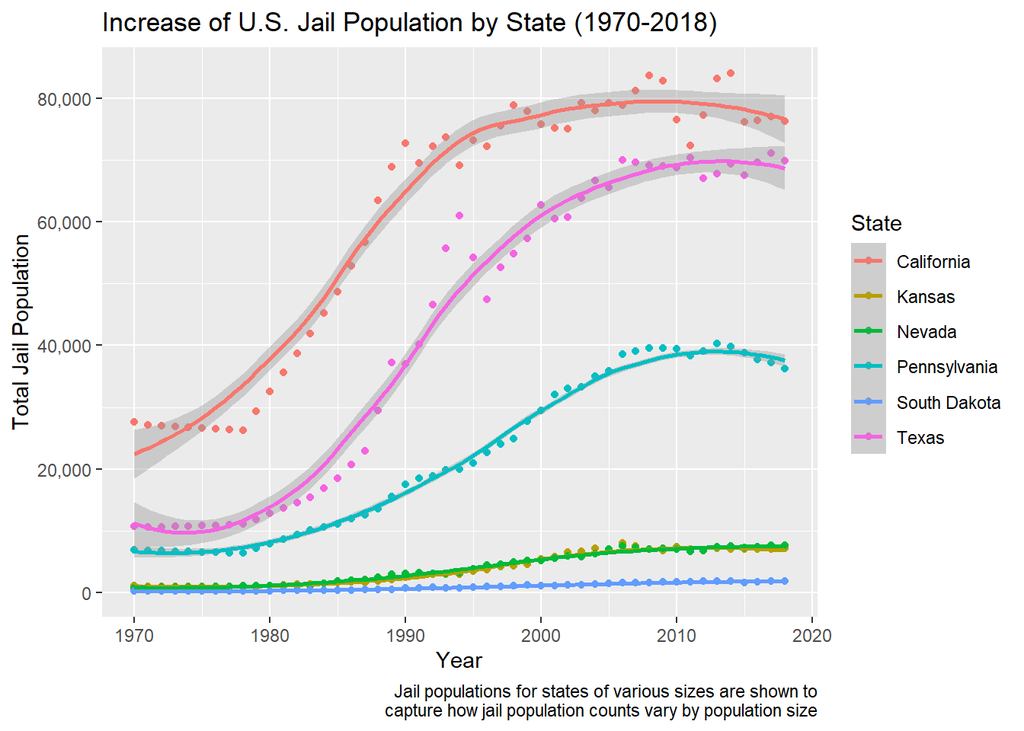

**How have state jail population counts changed over time in the United States?**

The above line chart shows the growth of state jail populations from 1970 to 2018 for the states of California, Kansas, Nevada, Pennsylvania, South Dakota, and Texas. These states were selected to show how jail populations tend to grow at a faster rate in states with higher population counts, such as California and Texas, than states with lower population counts, such as South Dakota. In most cases, jail population counts steadily increased between 1980 and the mid 2000s, after which these counts began to stabilize or taper slightly.

## Changes in Jail Population Rates by Gender Across Regions of the United States

[figure not shown]

**How have jail population rates changed by gender and region of the U.S. since 1980?**

Although the previous chart of U.S. jail population growth shows how the national jail population has risen in the past few decades, it fails to uncover the nuances in jail population demographics. By contrast, this chart of average jail population rates for men and women—as separated by U.S. region—reveals how in general, the jail population rate of men has increased at a larger rate than that of women since 1980. The most notable feature of this chart, however, is the fact that certain regions of U.S. appear to have higher jail growth rates than others. For instance, the jail population rates of both men and women saw the greater growth in the Southern region of the United States than in the Midwest or the Northeast. A question for further analysis could be how these observations correlate to population makeup in each of these regions, for it’s possible that the higher jail population rates in regions like the South are tied to racial inequality.

## Racial Groups with the Highest Incarceration Rates by County

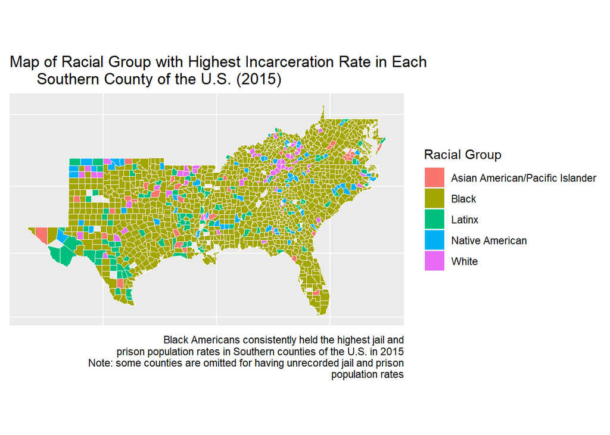

**Which racial groups had the highest incarceration rates across Southern counties in 2015?**

The above choropleth map clearly demonstrates some of the key racial disparities associated with mass incarceration. Namely, black Americans, represented by the olive color, are the most prevalent group on the map; that is, they account for the highest combined jail and prison population rates in the South. This finding is consistent with the population trends of and historic prejudice against black Americans living in the South, and it acts as a reminder that the issue of mass incarceration cannot be fully addressed without some acknowledgement that certain racial groups, and especially black Americans, are incarcerated at severely higher rates than others. This begs the question of whether or not black Americans also hold the highest jail and prison population rates in other regions of the United States, such as the West, where their population counts are not quite as high relative to other racial groups.

## References

- Ava Duvernay, and Jason Moran. *13TH*. USA, 2016.
- Ram Subramanian, Christian Henrichson, and Jacob Kang-Brown. *In Our Own Backyard: Confronting Growth and Disparities in American Jails*. New York, NY: Vera Institute of Justice, 2015.